# Hypothesis Testing

Peter Jantsch

2023-10-30

## Confidence interval

Let’s say we are interested in estimating the proportion of people who get more than 10 hours of sleep. We will first create a new data set with a new variable that records “yes” if they get more than 10, and “no” if not.

```r
sleep_10plus <- yrbss %>%
  mutate(sleep_10plus_ind = ifelse(school_night_hours_sleep == "10+", "yes", "no")) %>%
  drop_na(sleep_10plus_ind)
```

```r
sleep_10plus %>% count(sleep_10plus_ind)
```

```
## # A tibble: 2 × 2
##   sleep_10plus_ind     n
##   <chr>            <int>
## 1 no               12019
## 2 yes                316
```

Now let’s build a 90% CI for the proportion of students who get 10+ hours of sleep per night.

```r
sleep_10plus %>%
  specify(response = sleep_10plus_ind, success = "yes") %>%
  generate(reps = 1000, type = "bootstrap") %>%
  calculate(stat = "prop") %>%
  get_ci(level = 0.90)
```

```
## # A tibble: 1 × 2
##   lower_ci upper_ci
##      <dbl>    <dbl>
## 1   0.0233   0.0281
```

## Hypothesis Testing

```r
yrbss <- yrbss %>%
  mutate(sleep_10plus_ind = ifelse(school_night_hours_sleep == "10+", "yes", "no")) %>%
  mutate(strength_7d_ind = ifelse(strength_training_7d == "7", "yes", "no")) %>%
  drop_na(sleep_10plus_ind, strength_7d_ind)

yrbss %>%
  specify(response = strength_7d_ind, success = "yes") %>%
  calculate(stat = "prop", na.rm = TRUE)
```

```
## Response: strength_7d_ind (factor)
## # A tibble: 1 × 1
##    stat
##   <dbl>
## 1 0.167
```

```r
sleep_10plus <- yrbss %>%
  filter(sleep_10plus_ind == "yes")
```

## Step 1: Prepare

The proportion we are interested in is p = (the proportion of students that sleep 10+ hours a night that also strength train every day).

Null hypothesis: The proportion of students that sleep 10+ hours a night that also strength train every day is 0.167

Alternative hypothesis: The proportion of students that sleep 10+ hours a night that also strength train every day is NOT 0.167

In symbols:

$$H_0: p= 0.167 \qquad H_A: p \neq 0.167$$

## Step 2: Check

1. Independence: We have a random sample of students
2. Success-failure: We have more than 10 that strength train every day and more than 10 that don’t (see below)

```r
sleep_10plus %>% count(strength_7d_ind)
```

```
## # A tibble: 2 × 2
##   strength_7d_ind     n
##   <chr>           <int>
## 1 no                228
## 2 yes                84
```

## Step 3: Calculate the test statistic and the p-value

What proportion do we see in our sample? This is $\hat p$.

```r
obs_prop <- sleep_10plus %>%
  specify(response = strength_7d_ind, success = "yes") %>%
  calculate(stat = "prop", na.rm = TRUE)
obs_prop # this is p_hat
```

```
## Response: strength_7d_ind (factor)
## # A tibble: 1 × 1
##    stat
##   <dbl>
## 1 0.269
```

Is this much bigger than 0.167? Let’s take a look.

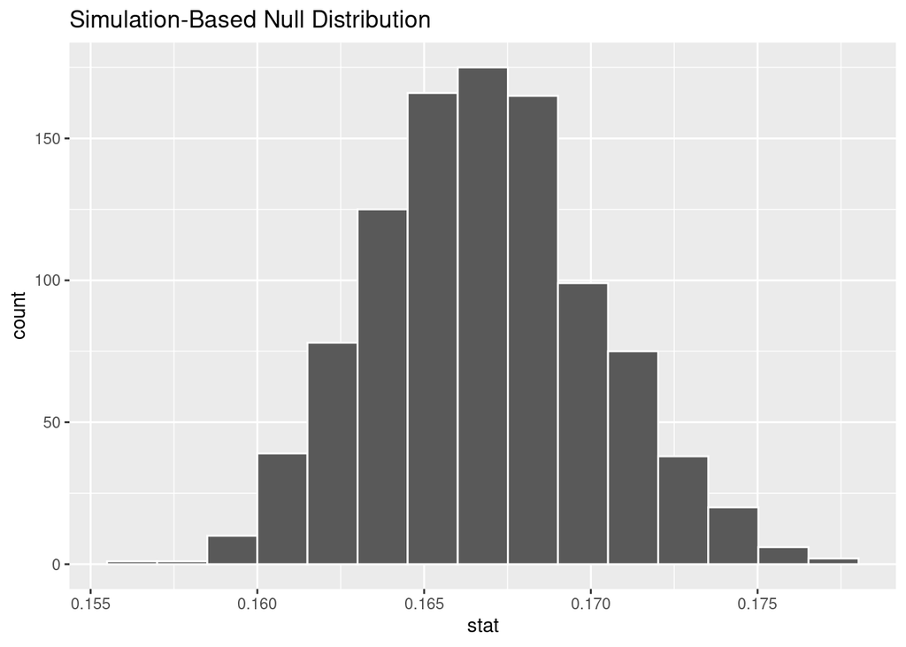

```r
null_dist <- yrbss %>%
  specify(response = strength_7d_ind, success = "yes") %>%
  hypothesize(null = "point", p = .167) %>%
  generate(reps = 1000, type = "draw") %>%
  calculate(stat = "prop", na.rm = TRUE)
null_dist %>% visualize()
```

Out of the 1000 simulated sample proportions, 0/1000 of them are .2692 or more. So the p-value is approximately 0/1000 = 0.

```r
null_dist %>%
  get_p_value(obs_stat = obs_prop, direction = "two-sided")
```

```
## # A tibble: 1 × 1
##   p_value
##     <dbl>
## 1       0
```

This is a very small p-value!

## Step 4: Conclude

With a p-value of approximately 0, we reject the null hypothesis. We conclude that the true proportion of students who strength train 7 days a week and sleep 10+ hours is not 0.167.

A 89% CI for the true proportion is (.234, .308).

```r
set.seed(10302023)
sleep_10plus %>%
  specify(response = strength_7d_ind, success = "yes") %>%
  generate(reps = 1000, type = "bootstrap") %>%
  calculate(stat = "prop", na.rm = TRUE) %>%
  get_ci(level = 0.89)
```

```
## # A tibble: 1 × 2
##   lower_ci upper_ci
##      <dbl>    <dbl>
## 1    0.234    0.308
```